# Lab 7: Simulations Answers

Week 3 Session 7

07/13/2020

```r
set.seed(447872364)
```

## Quiz Answers

**Quiz question 1** : What happens if you replace `numeric(1)` in the above code with `numeric(2)`?

**Answer** : This would return an error because the function `function(i) { sum(rexp(n = nexps, rate = rate))}` returns a single (length = 1) numeric value.

**Quiz question 2** : What if you replace `numeric(1)` by `character(1)`?

**Answer** : This again returns an error as `function(i) { sum(rexp(n = nexps, rate = rate))}` returns a numeric value and not a character value.

**Quiz question 3** : What is the most common outcome of a Binomial distribution with parameters `prob=0.4` and `size=20`?

**Answer** : The most common outcome is 8.

Simulation based answer:

```r
num_trials <- 10000
binom_variable <- rbinom(n = num_trials, prob = 0.4, size = 20)
freqs <- table(binom_variable)
freqs
```

```
## binom_variable
##    1    2    3    4    5    6    7    8    9   10   11   12   13   14   15   16
##    5   25  123  386  755 1252 1659 1797 1559 1113  701  368  177   64   11    5
```

```r
names(freqs)[which.max(freqs)]
```

```
## [1] "8"
```

Distribution based answer:

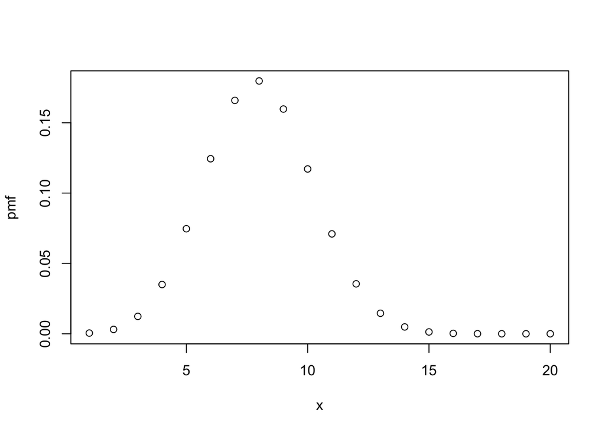

```r
x <- 1:20
# Probability Mass Function (discrete version of a pdf)
pmf <- dbinom(x, prob = 0.4, size = 20)
# Plot the distribution of Binomial Variable with specified parameters
# Then, look for the x-value which hives the highest probability density
plot(x = x, y = pmf)
```

**Quiz question 4** : What is the probability of the most common outcome of a Binomial distribution with parameters `prob=0.4` and `size=20`?

**Answer** : The probability of the most common outcome is around 0.1797058.

```r
dbinom(x = 8, prob = 0.4, size = 20)
```

```
## [1] 0.1797058
```

**Quiz question 5** : What is the most common outcome for a Geometric distribution with parameter `prob=0.2`?

**Answer** : The most common outcome is 0.

Simulation based answer:

```r
num_trials <- 10000
binom_variable <- rgeom(n = num_trials, prob = 0.2)
freqs <- table(binom_variable)
freqs
```

```
## binom_variable
##    0    1    2    3    4    5    6    7    8    9   10   11   12   13   14   15
## 1995 1636 1278  996  824  698  509  446  348  249  187  149  138  106   89   71
##   16   17   18   19   20   21   22   23   24   25   26   27   28   29   30   31
##   57   41   35   23   24   21   20   11   11    5    2    4    4    3    8    2
##   32   33   34   35   36   40   42
##    2    1    2    1    2    1    1
```

```r
names(freqs)[which.max(freqs)]
```

```
## [1] "0"
```

Distribution based answer:

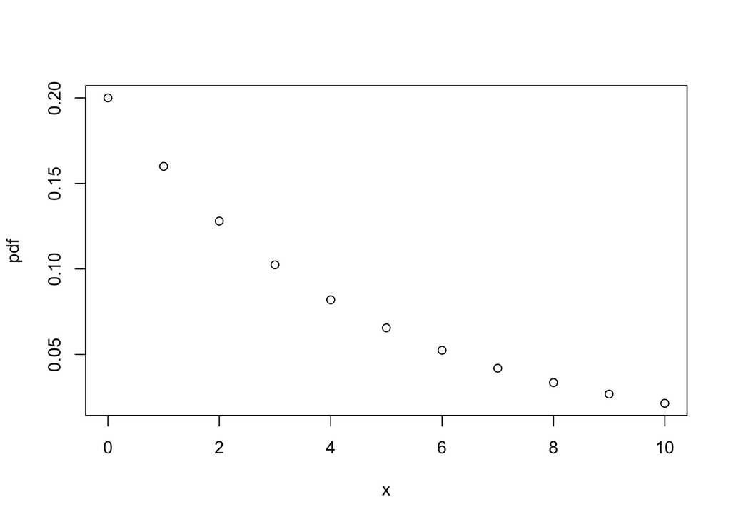

```r
x <- 0:10
pdf <- dgeom(x, prob = 0.2)
# Plot the distribution of Binomial Variable with specified parameters
plot(x = x, y = pdf)
```

**Quiz question 6** : What is the smallest $n$ such that a random variable drawn from a Geometric distribution with parameter `prob=0.2` is less or equal to $n$ with probability greater or equal to $0.95$?

**Answer** : The smallest $n$ is 13.

```r
ns_cutoff <- 0:100 #100 arbitrary, large number
ns_cutoff[min( which(pgeom(ns_cutoff, prob=0.2) >= 0.95))]
```

```
## [1] 13
```

An alternative way to arrive at the same result is using the `qgeom` function:

```r
qgeom(p = 0.95, prob = 0.2)
```

```
## [1] 13
```

**Quiz question 7** : What is the most common outcome for a Geometric distribution with parameter `prob=0.8`?

**Answer** : The most common outcome is 0.

Simulation based answer:

```r
num_trials <- 10000
binom_variable <- rgeom(n = num_trials, prob = 0.8)
freqs <- table(binom_variable)
freqs
```

```
## binom_variable
##    0    1    2    3    4    5
## 8003 1619  314   56    7    1
```

```r
names(freqs)[which.max(freqs)]
```

```
## [1] "0"
```

Distribution based answer:

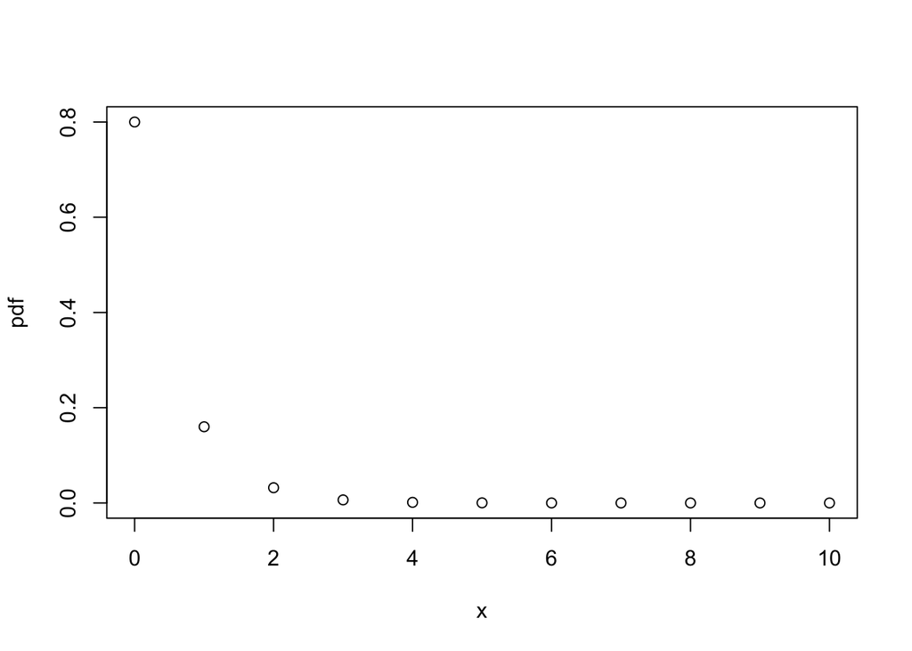

```r
x <- 0:10
pdf <- dgeom(x, prob = 0.8)
# Plot the distribution of Binomial Variable with specified parameters
plot(x = x, y = pdf)
```

**Quiz question 8** : What is the smallest $n$ such that a random variable drawn from a Geometric distribution with parameter `prob=0.8` is less or equal to $n$ with probability greater or equal to $0.95$?

**Answer** : The smallest $n$ is 1.

```r
ns_cutoff <- 0:100 #100 arbitrary, large number
ns_cutoff[min( which(pgeom(ns_cutoff, prob=0.8) >= 0.95))]
```

```
## [1] 1
```

Using `qgeom`:

```r
qgeom(p = 0.95, prob = 0.8)
```

```
## [1] 1
```

**Quiz question 9** : Find by simulations using the `var` function what the variance of the Poisson distribution with parameter `lambda = 5` is ( +/- 0.3 deviation accepted). For example you might want to generate 1000 instances of a Poisson(5) random variable.

**Answer** : The variance is about 5.

```r
num_trials <- 50000
var(rpois(n = num_trials, lambda = 5))
```

```
## [1] 5.00235
```

Note that the theoretical variance of Poisson variables is equal to lambda parameter, so we got a consistent answer.

**Quiz question 10** : Now instead consider the sum of 50 independent Poisson (0.1) random variables. Again using simulation (or otherwise), find the variance of this (again within +/- 0.3 range accepted).

**Answer** : The variance is about 5.

```r
num_trials <- 50000
var(replicate(num_trials, sum(rpois(n = 50, lambda = 0.1))))
```

```
## [1] 4.978917
```

Note, that we again get the same answer. This is because, a sum of Poisson variables, $X_i \sim Pois(\lambda_i), \quad i = 1, \dots, M$ is Poisson distributed $Y = \sum_{i = 1}^M X_i \sim Pois(\sum_{i = 1}^M\lambda_i)$

**Quiz Question 11** : How many chromosomes are stored in `Celegans`?

**Answer** : There are 7 chromosomes

```r
library("BSgenome.Celegans.UCSC.ce2")
library("Biostrings")
Celegans
```

```
## Worm genome:
## # organism: Caenorhabditis elegans (Worm)
## # provider: UCSC
## # provider version: ce2
## # release date: Mar. 2004
## # release name: WormBase v. WS120
## # 7 sequences:
## #   chrI   chrII  chrIII chrIV  chrV   chrX   chrM
## # (use 'seqnames()' to see all the sequence names, use the '$' or '[[' operator
## # to access a given sequence)
```

```r
length(Celegans)
```

```
## [1] 7
```

**Quiz Question 12** : What is the length of all chromosomes stored in `Celegans` combined? (Hint: Look at the documentation of the `BSgenome` class.)

**Answer** : Combined length is 100291769.

```r
sum(seqlengths(Celegans))
```

```
## [1] 100291769
```

**Quiz Question 13** : Which is the smallest chromosome of `Celegans`?

**Answer** : The smallest is the chromosome chrM.

```r
which.min(seqlengths(Celegans))
```

```
## chrM
##    7
```

**Quiz Question 14** : Based on these results, do you believe that the nucleotide frequencies in the *C.elegans* chrM sequence are all the same?

```r
# nucleotide frequency of chrM
lfM = letterFrequency(Celegans$chrM, letters=c("A", "C", "G", "T"))
lfM
```

```
##    A    C    G    T
## 4335 1225 2055 6179
```

We're going to compute a statistic that measures how close two multionial outputs are to each other as sum of squared deviation from expected frequencies over expected frequencies. We'll take the average squared difference between expected (`e`) and observed (`o`) counts, scaled by `e`. We will call the function `oestat`:

```r
oestat = function(o, e){
  sum( (e-o)^2/e )
}
n = length(Celegans$chrM)
expected = rep(n/4 ,4)
oe = oestat( o = lfM, e=expected)
oe
```

```
## [1] 4386.634
```

Then, we compute the distribution of the same statistics assuming it came from the null distribution if all nucleotides were equally likely:

```r
set.seed(1)
B = 10000
oenull = replicate(B, oestat(e=expected, o=rmultinom(1,size = n, prob = rep(1/4,4))))
```

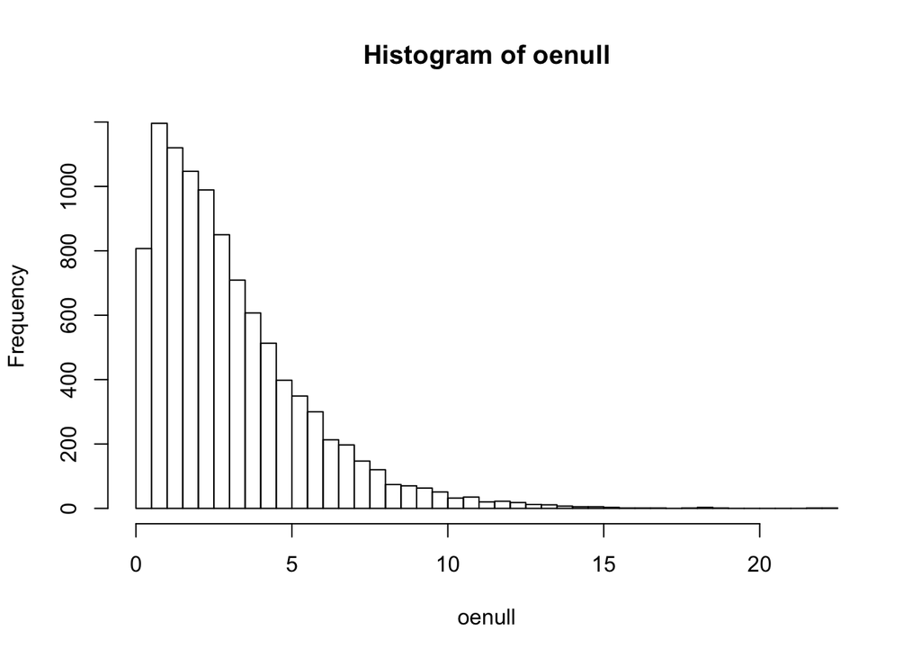

```r
hist(oenull, breaks = 50)
```

```r
quantile(oenull, p = 0.95)
```

```
##      95%
## 7.754444
```

```r
oe
```

```
## [1] 4386.634
```

```r
oe > quantile(oenull, p = 0.95)
```

```
##  95%
## TRUE
```

**Answer** : The observed statistic 'oe' is much bigger than the 95% quantile of the empirical null distribution of the statistics, so we can conclude that Celegans's chrM does not have an even distribution of the nucleotides.

## In Class Exercices

1. You want to invest in Netflix stock options. You know that the log return follows a normal distribution, such that:
   $$\log(\frac{p_{t+1}}{p_t}) \sim Normal(\mu = 0.001, \sigma^2= 0.01)$$
   In other words,

$$p_{t+1} = p_t * exp(N(\mu, \sigma^2))$$

```r
B = 10000
price= matrix(0, B, 100 +1)  ### B x 101 dimensional matrix
price[,1] = 1
mu = 0.001
sd1 = sqrt(0.01)

for (t in 1:100){
  price[, t+1] = sapply(price[,t], function(x){x * exp(rnorm(1, mu, sd1)) })
}
```

1. If you invest, what is the probability of the price being at least double what it was at day 100 compared to at day 0?

__ First solution__

$$\log(\frac{p_{100}}{p_0}) = \sum_{t=1}^{100}\log(\frac{p_{t}}{p_{t-1}}) \sim N(0.1, 1)$$
$$\implies \frac{p_{100}}{p_0} \geq 2 \iff N(0.1,1) \geq log(2) =0.69$$

```r
1-pnorm(0.69, mean=0.1,sd=1)
```

```
## [1] 0.2775953
```

**Simulation based solution**

```r
B = 1000
price = matrix(0, B, 100+1)
price[,1] =1
for(t in 1:100){
  price[,t+1] = sapply(price[,t], function(x){x * exp(rnorm(1, 0.001,sqrt(0.01)))})
}
```

```r
mean(price[,101]>=2)
```

```
## [1] 0.256
```

2. How long does it typically take for the price to double?

```r
B = 1000
T = apply(price,1, function(x){ifelse(max(x)>2, which(x>=2)[1], 0)})
print(mean(T[T>0]))
```

```
## [1] 43.89914
```

3. Imagine a strategy where at day 1, you invest 100 dollars, buying 100 options at 1 dollar. You then cash out whenever your investment doubles (you sell), and re-invest 100 dollars. At the end of the 100 days, you sell what you have at the current price. What is your expected profit after 100 days? What is the probability that the profit exceeds 200 dollars? The probability that you loose money?

```r
profit = apply(price, 1,function(x){
  t = floor(max(log(x)/log(2)))
  if (t>=1){
    res = 0
    a = 1
    for (k  in 1:t){
      b=which(x>=2^k)[1] ### first time the price doubles
      res = res - 100 + 100/x[a]* x[b]  ### -investment + quantity bought  * price sold
      a = b
    }
    return(res)
  }else{
    - 100 + x[101] * 100/1
  }
})

print(mean(profit))
```

```
## [1] 59.05898
```

```r
print(mean(profit>200))
```

```
## [1] 0.171
```

```r
print(mean(profit<0))
```

```
## [1] 0.409
```

2. Your friend in the department of psychology is running an experiment to assess the negative effect of sugar on memory task. For that purpose, he wants to find two (equal) groups of people, who will be asked to remember a series of associations, one, after drinking a sugar-heavy ice-tea, and the other, after drinking a ``diet'' version of the previous with synthetic sugar. He supposes that the range of scores (from 0 to 50) will be normally distributed for each group and wants to detect a difference of at least 2 points. Preliminary results indicate that the standard deviation within the groups is roughly 5 points, and the mean for the control is roughly 60. How many candidates should he pick to be 95% sure that there is a difference? In other words, how many candidates should he pick to ensure that the difference in means in greater than what chance would yield in 95% of cases if the two groups were identically distributed?

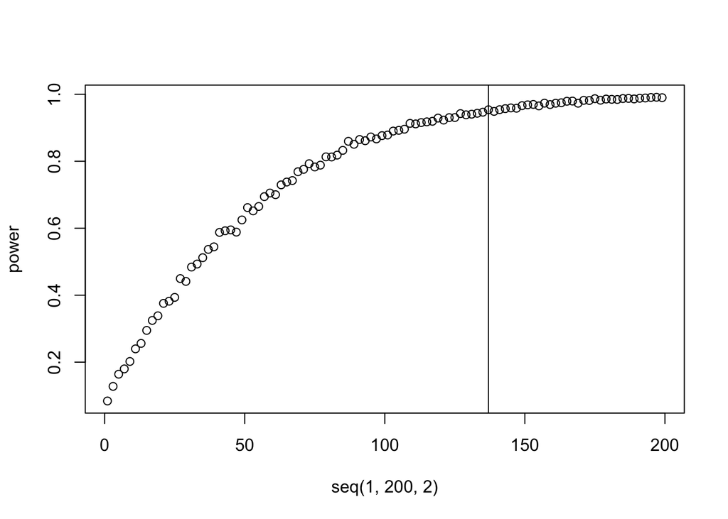

```r
B =5000
power_computation =function(x){
  thres = quantile(sapply(1:10000, function(y){mean(rnorm(x, 60,5))  - mean(rnorm(x, 60,5))} ),0.95)
  diff = sapply(1:B, function(y){
      G1= rnorm(x, 60,5)
      G2 = rnorm(x, 58,5)
      return(mean(G1) - mean(G2)> thres)
      #return(mean(G1) - mean(G2)> qnorm(0.95, 0, 2*5/sqrt(x))) ### simpler way
  })
  return(mean(diff))
}
power = sapply(seq(1,200,2), power_computation )
plot(seq(1,200,2), power)
abline(v = seq(1,200,2)[which(power > 0.95)[1]])
```